# Twitter Vaccination Sentiment Analysis

Alexandra Stephens

# Motivation

Vaccines have faced criticism from the beginning of development. However, recently in the United States and around the world, vaccination has faced increasing skepticism and vaccination rates have begun to decline. Anti-vaccination rhetoric is especially prevalent on social media where platforms serve as an open space for misinformation to spread.

The goal of this analysis is to download Twitter data and identify tweets as “pro” or “anti” vaccination. Tweets often have an associated location, thus this would allow researchers to locate communities where anti-vaccination sentiment is growing. This could help healthcare professionals identify communities that are at higher risk of infectious diseases.

In this document, we will provide methods on how to identify Twitter users and tweets that are “anti-vaccination.”

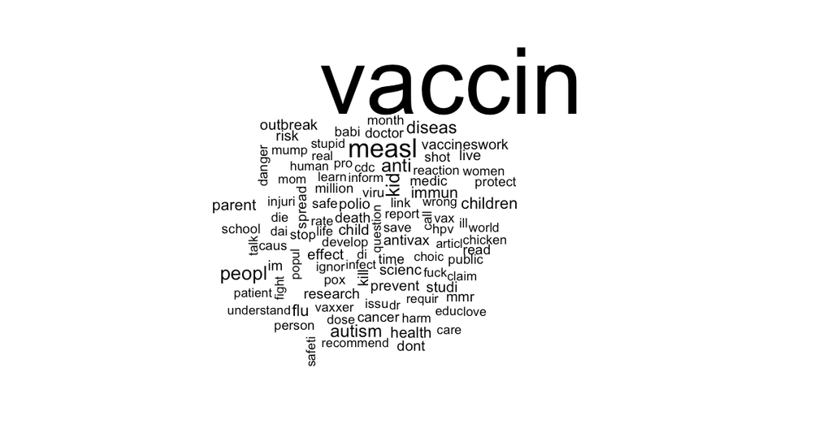

The libraries used in this study are listed in the following table, along with their purpose in this particular case study:

| Library | Purpose |
| --- | --- |
| `stringr` | Parsing text with regular expressions |
| `tidytext` | Loading relevant NLP datasets and manipulating text data |
| `dplyr` | Dataframe manipulation |
| `ggplot2` | Plotting sentiment |
| `wordcloud` | Creating wordcloud visuals |
| `SnowballC` | Word stemming |
| `tm` | Document Term Matrix Class |
| `topicmodels` | Applying Latent Dirichlet allocation |
| `kableExtra` | Formatting output into tables |
| `localgeo` | Converting city data to latitude and longitude |

In order to run this code please ensure you have these packages installed.

If you would like to download your own Twitter data, you will need to sign up for a Twitter developer account, create an application, and enter your own keys & credentials in the “What is the data?” section below.

The learning objectives for this case study include data cleaning with regular expressions, data exploration and visualization using Natural Language Processing techniques, sentiment analysis, and topic modeling.

# What is the data?

To collect data from Twitter, we suggest using the `rtweet` package. If you would like to download your own Twitter data, you will need to sign up for a [Twitter developer account](https://developer.twitter.com/en/apply-for-access.html), create an application, and enter your own keys in the R code chunk below. Note that we’ve set the code chunk `eval = false` so it is ignored when this file is knit.

```r
library(rtweet)

twitter_token <- create_token(
  app = "twitter_app_name",
  consumer_key = "XXXXXXXXXXXXXXX",
  consumer_secret = "XXXXXXXXXXXXXXXXXXXXX",
  access_token = "XXXXXXXXXXXXXXXXXXXXXXXXXXX",
  access_secret = "XXXXXXXXXXXXXXXXX")
```

Once the `twitter_token` is created it is stored in the workspace and you are free to use all the functions in `rtweet`!

The `search_tweets` function can download 18,000 every 15 minutes (with the free developer account). However adding `retryonratelimit = TRUE` automatically waits for the rate limit to be reset (after 15 min) and then searches for the remaining tweets. This is repeated until all requested tweets are downloaded.

We search for the 5,000 most recent tweets using the option `type = "recent"` that contain the terms “antivax”, “provax”, “vaccineswork”, “vaccinesdontwork”, or “vaccines”. `include_rts = TRUE` means we are including retweets. This is important for this case study: we want to be able to connect users to one another if they share the same opinion. We will assume if a user retweets a tweet without adding any text to it (which might state their opposition to the tweet) then they agree with the tweet.

We set `lang = "en"` to capture only tweets in English.

```r
st <- search_tweets('antivax OR vaccines OR vaccineswork OR vaccine OR vaccinesdontwork OR provax',
                    n = 5000,
                    type = "recent",
                    include_rts = TRUE,
                    lang = "en")

st <- lat_lng(st) #note
```

After collecting the tweets with the `rtweet` package, we exported the data as a csv file. This is an important step because the data you collect with the API can be very different every time. It also takes a few minutes to download new tweets.

Before exporting as a CSV we removed the columns that contained lists because this is not compatible for export.

```r
for (col in colnames(st))
  {
  if (typeof(st[[col]]) == "list")
    {
    st[[col]] <- NULL
  }
}
```

# Data import

Before doing anything, we should load the libraries needed for the case study.

```r
library(dplyr)
library(tidytext)
library(ggplot2)
library(stringr)
library(kableExtra)
library(wordcloud)
library(SnowballC)
library(localgeo)
library(tm)
library(topicmodels)
```

Now we import the data as a dataframe with `read.csv` and look at all the fields/columns by printing out the `colnames.` Note that each row of the dataframe contains information about *one tweet*. We print out the first row with `head(tweets_df,1)` to get an idea of what kind of information is in each row and column.

```r
tweets_df <- read.csv("data/twitter_data.csv",
                      stringsAsFactors = FALSE,
                      encoding="UTF-8")
colnames(tweets_df)
```

```
##  [1] "status_id"               "created_at"
##  [3] "text"                    "source"
##  [5] "display_text_width"      "reply_to_status_id"
##  [7] "is_quote"                "is_retweet"
##  [9] "favorite_count"          "retweet_count"
## [11] "ext_media_type"          "lang"
## [13] "quoted_status_id"        "quoted_text"
## [15] "quoted_created_at"       "quoted_source"
## [17] "quoted_favorite_count"   "quoted_retweet_count"
## [19] "quoted_followers_count"  "quoted_friends_count"
## [21] "quoted_statuses_count"   "quoted_location"
## [23] "quoted_description"      "quoted_verified"
## [25] "retweet_status_id"       "retweet_text"
## [27] "retweet_created_at"      "retweet_source"
## [29] "retweet_favorite_count"  "retweet_retweet_count"
## [31] "retweet_followers_count" "retweet_friends_count"
## [33] "retweet_statuses_count"  "retweet_location"
## [35] "retweet_description"     "retweet_verified"
## [37] "place_url"               "place_name"
## [39] "place_full_name"         "place_type"
## [41] "country"                 "country_code"
## [43] "location"                "description"
## [45] "url"                     "protected"
## [47] "followers_count"         "friends_count"
## [49] "listed_count"            "statuses_count"
## [51] "favourites_count"        "account_created_at"
## [53] "verified"                "account_lang"
## [55] "lat"                     "lng"
## [57] "uuidgens_user"           "uuidgens_retweet"
## [59] "uuidgens_quote"
```

```r
head(tweets_df,1)
```

```
##      status_id          created_at
## 1 1.095809e+18 2019-02-13 22:15:38
##                                                                                                             text
## 1 @twitter_handle @twitter_handle No additional abortions need to be performed to continue creating the vaccine.
##               source display_text_width reply_to_status_id is_quote
## 1 Twitter Web Client                 78       1.095808e+18    FALSE
##   is_retweet favorite_count retweet_count ext_media_type lang
## 1      FALSE              0             0             NA   en
##   quoted_status_id quoted_text quoted_created_at quoted_source
## 1               NA        <NA>              <NA>          <NA>
##   quoted_favorite_count quoted_retweet_count quoted_followers_count
## 1                    NA                   NA                     NA
##   quoted_friends_count quoted_statuses_count quoted_location
## 1                   NA                    NA            <NA>
##   quoted_description quoted_verified retweet_status_id retweet_text
## 1               <NA>              NA                NA         <NA>
##   retweet_created_at retweet_source retweet_favorite_count
## 1               <NA>           <NA>                     NA
##   retweet_retweet_count retweet_followers_count retweet_friends_count
## 1                    NA                      NA                    NA
##   retweet_statuses_count retweet_location retweet_description
## 1                     NA             <NA>                <NA>
##   retweet_verified place_url place_name place_full_name place_type country
## 1               NA      <NA>       <NA>            <NA>       <NA>    <NA>
##   country_code                    location
## 1         <NA> High in the Rocky Mountains
##                                                                                                     description
## 1 A simple country Democrat, who loves God and USA, and dreams of a world without violence, bigotry or poverty.
##                       url protected followers_count friends_count
## 1 https://t.co/3z9yfjCDh8     FALSE            4544          5001
##   listed_count statuses_count favourites_count  account_created_at
## 1            2           7096            10536 2016-04-14 15:07:53
##   verified account_lang lat lng                        uuidgens_user
## 1    FALSE           en  NA  NA a9c0a85d-f02c-4185-bbc8-ba1aab670e33
##   uuidgens_retweet uuidgens_quote
## 1             <NA>           <NA>
```

We describe a few of the notable columns in the following table as they relate to the first row of the data.

| Column | Description | Value |
| --- | --- | --- |
| `text` | Raw tweet text | @twitter_handle @twitter_handle No additional abortions need to be performed to continue creating the vaccine. |
| `uuidgens_user` | Unique ID of the user who tweeted (or retweeted) this tweet | a9c0a85d-f02c-4185-bbc8-ba1aab670e33 |
| `uuidgens_retweet` | Unique ID of the user that this tweet was *retweeted from* | NA |
| `created_at` | Date and time tweet was tweeted | 2019-02-13 22:15:38 |
| `display_text_width` | Number of characters in tweet | 78 |
| `location` | Location the tweeting user has listed in their Twitter bio | High in the Rocky Mountains |
| `description` | Description the tweeting user has listed in their Twitter bio | A simple country Democrat, who loves God and USA, and dreams of a world without violence, bigotry or poverty. |
| `long` and `lat` | Longitude and latitude coordinates of the user when tweet was created |  |

“NA” in the `uuidgens_retweet` row indicates the tweet was not a retweet, which we can also see in the column `is_retweet` where the value is “FALSE”.

We point out that the columns beginning with “uuidgens” did not come with `rtweet` package. They were generated in a separate file to remove identifiers to avoid assuming or exploiting political or religious views and/or the state of someone’s health. When importing the data with `rtweet`, there are many columns with identifiers. Each tweet has an associated user `screen_name` (usually referred to as the user’s Twitter handle), a `name`, and `user_id.` Every Twitter user has a unique user ID, however these IDs are publicly traceable to the user names. Thus, all of these fields need to be removed, as well as related fields such as `retweet_user_id.` Here is how we created the IDs:

- We first found all the unique user IDs from the columns `user_id`, `quoted_user_id`, and `retweet_user_id` with `unique_ids <- unique(c(d$user_id, d$retweet_user_id, d$quoted_user_id))`.
- Then, we generated as many unique IDs as we had unique users with `dplR::uuid.gen` and created a dataframe with two columns: one with the original unique IDs, and the second with the generated unique IDs.
- We merged this data three separate times with the tweets dataframe on the columns `user_id`, `quoted_user_id`, and `retweet_user_id` columns to create the columns `uuidgens_user`, `uuidgens_retweet`, and `uuidgens_quote.`

To see the exact code, please refer to the appendix.

# Data wrangling

## Cleaning with regular expressions

```r
head(unique(tweets_df$text),10)
```

```
##  [1] "@twitter_handle @twitter_handle No additional abortions need to be performed to continue creating the vaccine."
##  [2] "@twitter_handle The cells were obtained more than 50 years ago, as a result of elective abortions — and today the cells are more than three generations removed from their origin. https://t.co/6T8qxdKkW3"
##  [3] "Sad but true. Thanks anti-vaxers! #antivax #VaccinesWork #VaccinateYourKids #science https://t.co/h2N8Y29Im3"
##  [4] "Gizmo, a 10-year-old male Rex cat, came in despite the weather for his annual exam and vaccines. Great job Gizmo! Good health takes priority.  #rexcat #bothellpethosp #catsofinstagram #catsoftwitter #meow #vetmed #vettechs #animalspnw https://t.co/jJpkAqBu4z"
##  [5] "@twitter_handle My children’s daycare director received the polio vaccine in the 70’s. Ended up getting it as a result. She has no feeling or movement in her legs and has to use crutches. Yet.....she still requires every child to be fully vaccinated. Bc she’s smart and knows death is worse.…
##  [6] "@twitter_handle @twitter_handle My children’s daycare director received the polio vaccine in the 70’s. Ended up getting it as a result. She has no feeling or movement in her legs and has to use crutches. Yet.....she still requires every child to be fully vaccinated. Bc she’s smart and knows…
##  [7] "Deliberate disinformation is behind a massive measles outbreak in Washington https://t.co/cJYbbSjYtK https://t.co/zUSYZuAO07"
##  [8] "@twitter_handle @twitter_handle @twitter_handle Why are you even here except to be a advocate for chemical cocktails called vaccines.  If you have pumped your children full of them (actually child abuse), then wtf difference does it make if I choose to not to? If they work, your kids are \"…
##  [9] "The CDC declared that #Measles had been eliminated in the U.S. 19 years ago – but right now, there is an outbreak in 10 states. \n@twitter_handle Medical Contributor @twitter_handle joins @twitter_handle and @twitter_handle to discuss everything you need to know.\n \nhttps://t.co/MRxb4bkoHy…
## [10] "Sharyl Attkisson and measles vaccine math – wrong in so many ways https://t.co/vSic7TtNXX Via @twitter_handle "
```

From this small peak at the data, we can already see that there are a lot of strings that are not real words. We should remove text that does not help and, in fact, may hinder our analysis. For example, we observe lots of links (“https…”) and UTF characters or emojis (“\U000…”) that aren’t giving us any insightful information.

To do this, first we create a string named `pat` (short for *pattern*) that contains *regular expression* or “regex” patterns that match with various unwanted characters or phrases.

```r
pat <- "[\r\n]|&amp.|@.*?[ \t\r\n]|@.*?$|https:.*[ \t\r\n]|https:.*$|[^[:alpha:][ \t\r\n]?&/\\-#.']"
```

Note that the “|” character separates each pattern in the string. For example, the first pattern `[\r\n]` matches with newline characters, and is followed by a “|” to signify the end of that regular expression.

Let’s break down each of the strings in `pat` and explain what text it is meant to match with.

[output not shown]

Next, we break down one of the above patterns, `@.*?[ \t\r\n]`, to see how regular expressions work.

First, `@` simply matches with the @ sign, the beginning of tagging a user on Twitter. In regular expression “.” can match with any character except for newline `\n`. The “`*`” character matches 0 or more of the previous character. For example, `s*` matches with "“,”s“,”ssss“, etc. In this case we have `@.*`, so we are matching 0 or more of”." or any character. So now we have matched with anything beginning with @. Next, the “?” quantifier is *non-greedy*, meaning it matches as few characters as possible. We want to include this so that we remove the minimum amount of text and thus only the username tag. We stop removing text when we reach a space, tab, carriage return or newline character, `[ \t\r\n]`. Thus, `@.*?[ \t\r\n]` matches with any username that is retweeted or tagged. Let’s see what happens when we use only this pattern in `str_replace_all`, which matches all occurrences of the pattern (hence, the addition of `_all`). Each match is replaced with an empty string `""` thus removing the unwanted string.

```r
remove_handle <- tweets_df %>%
  mutate(text = str_replace_all(text, pattern = '@.*?[ \t\r\n]', "")) %>%
  mutate(retweet_text = str_replace_all(retweet_text, pattern = '@.*?[ \t\r\n]', ""))

head(remove_handle$text)
```

```
## [1] "No additional abortions need to be performed to continue creating the vaccine."
## [2] "The cells were obtained more than 50 years ago, as a result of elective abortions — and today the cells are more than three generations removed from their origin. https://t.co/6T8qxdKkW3"
## [3] "Sad but true. Thanks anti-vaxers! #antivax #VaccinesWork #VaccinateYourKids #science https://t.co/h2N8Y29Im3"
## [4] "Gizmo, a 10-year-old male Rex cat, came in despite the weather for his annual exam and vaccines. Great job Gizmo! Good health takes priority.  #rexcat #bothellpethosp #catsofinstagram #catsoftwitter #meow #vetmed #vettechs #animalspnw https://t.co/jJpkAqBu4z"
## [5] "My children’s daycare director received the polio vaccine in the 70’s. Ended up getting it as a result. She has no feeling or movement in her legs and has to use crutches. Yet.....she still requires every child to be fully vaccinated. Bc she’s smart and knows death is worse. \U0001f64c\U0001…
## [6] "My children’s daycare director received the polio vaccine in the 70’s. Ended up getting it as a result. She has no feeling or movement in her legs and has to use crutches. Yet.....she still requires every child to be fully vaccinated. Bc she’s smart and knows death is worse. \U0001f64c\U0001…
```

Great, it removed all the twitter handles found within the text!

Now we will remove the strings that match with the all the patterns in `pat` with `str_replace_all`. This time, it will check for matches with *every seperate pattern* in `pat` and again look for repeats of any pattern. We replace the `tweets_df` columns `text` and `retweet_text` with the cleaned versions of the columns by using `mutate`. We also replace double spaces with single spaces in case the removal of some phrases left extra spaces behind. We print the head of the `text` column to view our changes.

```r
tweets_df <- tweets_df %>%
  mutate(text = str_replace_all(text, pattern = pat, "")) %>%
  mutate(retweet_text = str_replace_all(retweet_text, pattern = pat, "")) %>%

  mutate(text = str_replace_all(text, pattern = "  ", " ")) %>%
  mutate(retweet_text = str_replace_all(retweet_text, pattern = "  ", " "))

head(unique(tweets_df$text))
```

```
## [1] "No additional abortions need to be performed to continue creating the vaccine."
## [2] "The cells were obtained more than years ago as a result of elective abortions and today the cells are more than three generations removed from their origin. "
## [3] "Sad but true. Thanks anti-vaxers #antivax #VaccinesWork #VaccinateYourKids #science "
## [4] "Gizmo a -year-old male Rex cat came in despite the weather for his annual exam and vaccines. Great job Gizmo Good health takes priority. #rexcat #bothellpethosp #catsofinstagram #catsoftwitter #meow #vetmed #vettechs #animalspnw "
## [5] "My childrens daycare director received the polio vaccine in the s. Ended up getting it as a result. She has no feeling or movement in her legs and has to use crutches. Yet.....she still requires every child to be fully vaccinated. Bc shes smart and knows death is worse. "
## [6] "Deliberate disinformation is behind a massive measles outbreak in Washington "
```

Now that the raw tweet text is clean, let’s start manipulating the tweets with natural language processing techniques to gain insight about our data.

## The tidy text and NLP

The tidy text format is using **one-token-per-row** in our dataframe. In short, tokens in natural language processing are words. To be technical, you could say a token is a list of characters between two spaces. Tokenization is the process of breaking up a string, paragraph, or document into tokens.

We want to tokenize our tweets, however we don’t want to lose any information. Specifically, we want to keep track of what Tweet each word came from since our analysis involves differentiating tweets. Other analyses including topic summarization may not require keeping track of this–you can just a create a jumble (i.e. “corpus”) of words and find commonalities.

First, we create the dataframe `text_df` with the `tweets_df` column `text` and add the `int` column as an index for the tweets.

```r
unique_indices <- order(tweets_df$text)[!duplicated(sort(tweets_df$text))]

text_df <- data.frame("text" = tweets_df$text[unique_indices])
text_df$int <- as.numeric(unique_indices)

text_df$text <- as.character(text_df$text)


text_df <- text_df[order(text_df$int),]
row.names(text_df) <- 1:nrow(text_df)

head(text_df)
```

```
##                                                                                                                                                                                                                                                                              text
## 1                                                                                                                                                                                                  No additional abortions need to be performed to continue creating the vaccine.
## 2                                                                                                                   The cells were obtained more than years ago as a result of elective abortions and today the cells are more than three generations removed from their origin.
## 3                                                                                                                                                                                            Sad but true. Thanks anti-vaxers #antivax #VaccinesWork #VaccinateYourKids #science
## 4                                           Gizmo a -year-old male Rex cat came in despite the weather for his annual exam and vaccines. Great job Gizmo Good health takes priority. #rexcat #bothellpethosp #catsofinstagram #catsoftwitter #meow #vetmed #vettechs #animalspnw
## 5 My childrens daycare director received the polio vaccine in the s. Ended up getting it as a result. She has no feeling or movement in her legs and has to use crutches. Yet.....she still requires every child to be fully vaccinated. Bc shes smart and knows death is worse.
## 6                                                                                                                                                                                                   Deliberate disinformation is behind a massive measles outbreak in Washington
##   int
## 1   1
## 2   2
## 3   3
## 4   4
## 5   5
## 6   7
```

Next, we tokenize the text data with tidytext’s `unnest_tokens` by using the `text` column as the input and `word` as the name of the output column. We replace `text_df` with this newly formatted dataframe.

```r
text_df <- text_df %>%
  unnest_tokens(word, text)

head(text_df,10)
```

```
##     int       word
## 1     1         no
## 1.1   1 additional
## 1.2   1  abortions
## 1.3   1       need
## 1.4   1         to
## 1.5   1         be
## 1.6   1  performed
## 1.7   1         to
## 1.8   1   continue
## 1.9   1   creating
```

Now that we have our data in a “tidy” format, we want to remove stop words from the text. *Stop words* in NLP are common words that don’t add value to a sentence, paragraph, document etc. For example, “still think the flu shot is…” doesn’t give us any extra information than “still think flu shot,” so we can remove “the” and “is” to make our dataset more concise.

You can find lists of stop words in the `stop_words` dataset, which has two columns: `word` and `lexicon`. There are three different lexicons that reference the *source* of the stop word:

- [onix](http://www.lextek.com/manuals/onix/stopwords1.html)
- [SMART](http://www.jmlr.org/papers/volume5/lewis04a/lewis04a.pdf)
- [snowball](http://snowball.tartarus.org/algorithms/english/stop.txt)

The difference between the lexicons is they include different words. Some include more than others, thus if we use these we remove more words and from our data. To quickly see these differences, we can count the number of stop words in each category using `dplyr::group_by`.

```r
data(stop_words)
head(stop_words)
```

```
## # A tibble: 6 x 2
##   word      lexicon
##   <chr>     <chr>
## 1 a         SMART
## 2 a's       SMART
## 3 able      SMART
## 4 about     SMART
## 5 above     SMART
## 6 according SMART
```

```r
stop_words %>%
    group_by(lexicon) %>%
    tally()
```

```
## # A tibble: 3 x 2
##   lexicon      n
##   <chr>    <int>
## 1 onix       404
## 2 SMART      571
## 3 snowball   174
```

At this point in the analysis, we have no prior reason to chose a specific lexicon, so let’s remove all of the stop words in the `stopwords` dataset from our data using the `anti_join` function. This will remove any word found in any of the three lexicons. We can always modify this later on.

```r
text_df <- text_df %>%
  anti_join(stop_words)
head(text_df,10)
```

```
##    int       word
## 1    1 additional
## 2    1  abortions
## 3    1  performed
## 4    1   continue
## 5    1   creating
## 6    1    vaccine
## 7    2      cells
## 8    2   obtained
## 9    2        ago
## 10   2     result
```

If you compare this dataframe to `text_df` before the anti-join, you notice that the words “no”, “to”, “be”, and “need” have been removed.

If we wanted to select a specific lexicon, such as the smallest set of stop words “snowball”, we would use `dplyr::filter` command as shown below.

```r
text_df <- text_df %>%
  anti_join(stop_words %>% filter(lexicon == "snowball"))
```

## Stemming

Another technique often used alongside removing stop words is word *stemming*. Stemming changes each word to a root word so that different conjugations of the same word are not treated as different words completely. A human can tell that “vaccine”, vaccinate" and “vaccination” have close to the same meaning. However, for example, if we were to count every repetition of “vaccine” in R we would not get an accurate total since “vaccination” would be ignored. Instead, we apply a stemming algorithm which changes each of those words to “vaccin.”

We will use the library `SnowballC` which implements the [Porter stemming algorithm](http://snowball.tartarus.org/algorithms/porter/stemmer.html). The command `SnowballC::wordStem` returns the stem of each word in a given vector.

```r
text_df_stemmed <- text_df %>%
  mutate(word = wordStem(word))
head(text_df_stemmed,10)
```

```
##    int    word
## 1    1   addit
## 2    1   abort
## 3    1 perform
## 4    1 continu
## 5    1   creat
## 6    1  vaccin
## 7    2    cell
## 8    2  obtain
## 9    2     ago
## 10   2  result
```

Since we’ve filtered and removed the most common English words–the stop words–let us also remove the most *uncommon* words in our dataset. This helps reduce the size of our data and remove meaningless words to this analysis, such as uncommon pronouns.

First, we create a temporary dataframe `temp` where each row contains a unique word from our data followed by the number of times this word is repeated in the dataset.

```r
temp <- text_df_stemmed %>%
  dplyr::count(word)
head(temp)
```

```
## # A tibble: 6 x 2
##   word         n
##   <chr>    <int>
## 1 a.m          2
## 2 a.schiff     1
## 3 aaa          1
## 4 aaasmtg      1
## 5 aah          1
## 6 aapi         1
```

Next we create a dataframe with the most uncommon words. We can start with words repeated only once.

```r
uncomm_words <- temp %>%
  filter(n == 1) %>%
  select(word)
uncomm_words
```

```
## # A tibble: 2,285 x 1
##    word
##    <chr>
##  1 a.schiff
##  2 aaa
##  3 aaasmtg
##  4 aah
##  5 aapi
##  6 abound
##  7 abovemajest
##  8 abstract
##  9 absurd
## 10 abt
## # … with 2,275 more rows
```

Now that we have a dataframe of uncommon words, we use the `dplyr::anti_join` function again to remove these words from the dataframe.

```r
text_df_stemmed_common <- text_df_stemmed %>%
  anti_join(uncomm_words)
nrow(text_df_stemmed)
```

```
## [1] 17823
```

```r
nrow(text_df_stemmed_common)
```

```
## [1] 15538
```

We have removed 2285 words.

# Exploratory data analysis

## Map visual

For a fun visual, we can visualize our tweets on a map. First let’s find which tweets use the word or hashtag “antivax” and which tweets say “vaccines work.” Next we add the column `Hashtags` that contains labels for if the tweet contains these words or contains neither.

```r
anti_lst <- as.numeric(
  grepl("antivax", tweets_df$text))
pro_lst <-as.numeric(
  grepl("vaccines work", tweets_df$text))

head(anti_lst)
```

```
## [1] 0 0 1 0 0 0
```

```r
tweets_df$Hashtags <- "none"
tweets_df$Hashtags[anti_lst == 1] <- "antivax"
tweets_df$Hashtags[pro_lst == 1] <- "vaccines work"
```

Next we use `ggplot2` to plot this on a map.

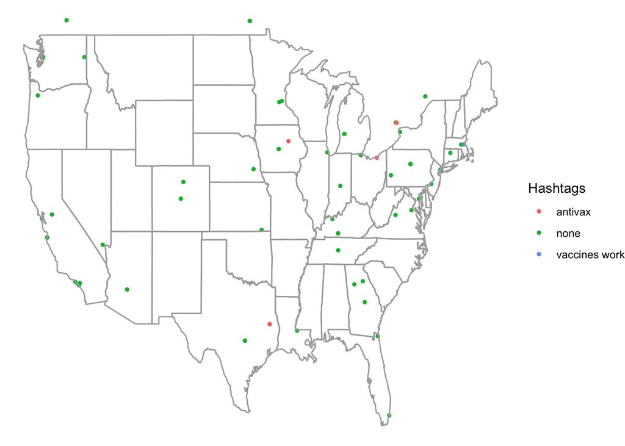

```r
states <- map_data("state")

ggplot(data = states) +
  geom_point(data = tweets_df, aes(x = lng, y = lat,  colour = Hashtags), size = 1) +
  geom_polygon(aes(x = long, y = lat, group=group), fill = NA, color = "dark grey") +
  theme_void()
```

As we can there is some missing latitude and longitude data. This is expected, since we assume most users do not have their location turned on on twitter. We calculate exactly what percentage of tweets do not have an associated latitude and longitude below.

```r
(have_lat = sum(is.na(tweets_df$lat) ==FALSE)/dim(tweets_df)[1]*100)
```

```
## [1] 1.34
```

We see that only 1.34 percent of tweets in this dataset have latitude and longitude coordinates.

```r
(have_hashtag = sum(tweets_df$Hashtags !="none")/dim(tweets_df)[1]*100)
```

```
## [1] 2.08
```

Additionally, only 2.08 percent of tweets contain the phrases “antivax” or “vaccines work,” so there is not much data on our map.

One solution to mitigate this lack-of-data issue is to use the `location` column. As described in the “Data import” section, this column contains the location a user lists in their Twitter bio. For example, users who live in Baltimore might write “Baltimore, MD.” Others are more creative and don’t put a real location, while others might write something more general such as “Maryland, USA.” Let’s print out some of the locations to observe.

```r
head(tweets_df$location,15)
```

```
##  [1] "High in the Rocky Mountains"    "High in the Rocky Mountains"
##  [3] "Tyler, Texas"                   "Bothell, WA"
##  [5] "West Fargo, North Dakota"       "West Fargo, North Dakota"
##  [7] "Washington, D.C."               "Charlotte, North Carolina, USA"
##  [9] "Manhattan, NY"                  "Toronto"
## [11] "Madison, WI"                    "New York City"
## [13] "Toronto"                        "Paradise"
## [15] "Washington, DC"
```

We see that the format of most of the locations is a little different, however there are a few with the form, “City, State Abbrv.” Using the package `localgeo`, let’s convert one of the location entries to latitude and longitude coordinates.

The function `localgeo::geocode` takes two strings as input: a city, starting with a capital letter, and a state abbreviation in all capital letters. `devtools::install_github("hrbrmstr/localgeo")`

```r
geocode("Baltimore","MD")
```

```
##         lon      lat
## 1 -76.61158 39.29076
```

```r
geocode("baltimore","MD")
```

```
##   lon lat
## 1  NA  NA
```

```r
geocode("Baltimore","Maryland")
```

```
##   lon lat
## 1  NA  NA
```

```r
geocode("Baltimore","md")
```

```
##   lon lat
## 1  NA  NA
```

Now we can see that we must put our data in the exact format needed for the package. We select the fourth row value, “Bothell, WA” to use as a test. We first split the entry “Bothell, WA” into two strings using `strsplit`. Then we remove the unwanted extra space, " ", with `str_replace_all`.

```r
(loc <- unlist(strsplit(tweets_df$location[4], "[,]")))
```

```
## [1] "Bothell" " WA"
```

```r
(loc2 <- str_replace_all(loc, pattern = " ", ""))
```

```
## [1] "Bothell" "WA"
```

```r
geocode(loc2[1],loc2[2])
```

```
##         lon      lat
## 1 -122.2075 47.75966
```

To make this apply more generally, let’s remove all spaces after commas before we split the strings.

```r
no_space <- str_replace_all(tweets_df$location, pattern = ", ", ",")
test_loc <- strsplit(no_space, "[,]")
test_loc[1:4]
```

```
## [[1]]
## [1] "High in the Rocky Mountains"
##
## [[2]]
## [1] "High in the Rocky Mountains"
##
## [[3]]
## [1] "Tyler" "Texas"
##
## [[4]]
## [1] "Bothell" "WA"
```

Next we use `sapply` to get all the element in the first column of each list. For the function in sapply, we select the whole column with the operator `'['`. Next, we specify which column we would like to select. In this case we are going use the first column as the city and the second column as the state abbreviation.

```r
cities <- sapply(test_loc,'[',1)
state_abbvs<- sapply(test_loc,'[',2)

lat_fromloc <- geocode(city=cities,state=state_abbvs)
head(lat_fromloc)
```

```
##         lon      lat
## 1        NA       NA
## 2        NA       NA
## 3        NA       NA
## 4 -122.2075 47.75966
## 5        NA       NA
## 6        NA       NA
```

```r
nrow(lat_fromloc)
```

```
## [1] 5001
```

Notice that there are 5001 rows when we were expecting 5000. Why is this so? After much digging, we find a bug in the package: using `geocode` on the city *Muskegon, MI* returns two rows instead of one. So we add a temporary fix to remove exactly one extra row.

```r
geocode("Muskegon", "MI")
```

```
##         lon      lat
## 1 -86.24875 43.23434
## 2 -86.26009 43.22845
```

```r
# temporary bug fix
if (nrow(lat_fromloc) == 5001){
  lat_fromloc <- lat_fromloc[-293,]
}
nrow(lat_fromloc)
```

```
## [1] 5000
```

Next, we add this data to the `lat` and `lng` columns with values `NA` and calculate how much of the total data now have latitude and longitude values.

```r
keep_lat <- is.na(tweets_df$lat) == FALSE
empty_lat <- is.na(tweets_df$lat)
tweets_df$lat[keep_lat][1:6]
```

```
## [1] 43.65323 41.49594 32.67821 37.09024 43.07557 25.76168
```

```r
lat_fromloc$lat[keep_lat][1:6]
```

```
## [1]       NA       NA       NA       NA 42.88678 25.77484
```

```r
tweets_df$lat[empty_lat] <- lat_fromloc$lat[empty_lat]
tweets_df$lng[empty_lat] <- lat_fromloc$lon[empty_lat]

(new_lat_percent = sum(is.na(tweets_df$lng) == FALSE)/dim(tweets_df)[1]*100)
```

```
## [1] 18.16
```

Using the `location` column data, we easily converted 18.16 percent of the data to latitude and longitude coordinates! Now we plot the map again to show how much more data we have now.

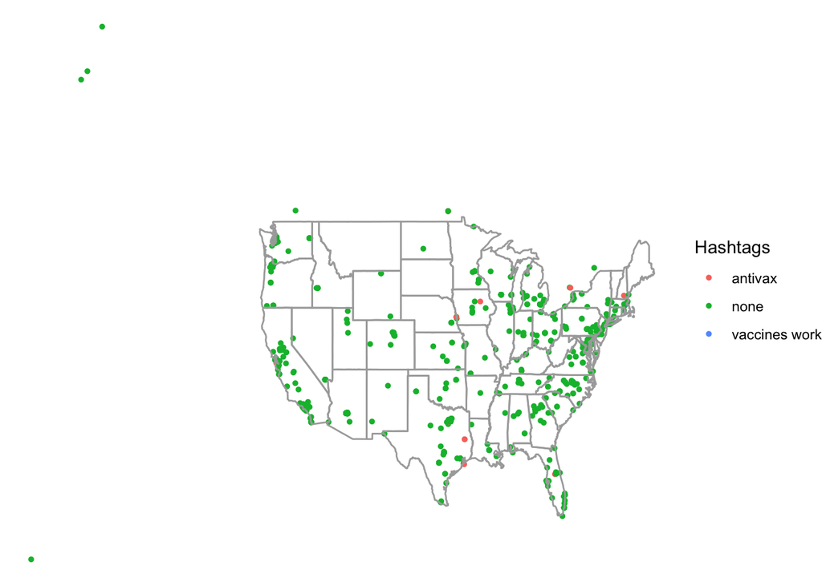

```r
ggplot(data = states) +
  geom_point(data = tweets_df, aes(x = lng, y = lat,  colour = Hashtags), size = 1) +
  geom_polygon(aes(x = long, y = lat, group=group), fill = NA, color = "dark grey") +
  theme_void()
```

There are other things we could do get more lattitude and longitude coordinates. We could convert state names (for example, “Maryland”) to their abbreviations (“MD”). We could also ensure the first letter of the city is capitalized and the rest of the letters are lowercase. These additional manipulations are left as an exercise.

## N-grams

A common NLP data exploration practice is looking at n-gram frequencies. *N-grams* are sequences of *n* items/tokens. Common n-grams that are used in NLP are unigrams, bigrams, and trigrams, meaning one word, two word, and three word combinations.

We find the top 10 most common words or unigrams to see common topics in our data. Recall that we have already removed stop words and unnecessary items such as web links, and we have stemmed the remaining words.

```r
unigram_count <- text_df_stemmed %>% dplyr::count(word, sort = TRUE)
head(unigram_count,20)
```

```
## # A tibble: 20 x 2
##    word         n
##    <chr>    <int>
##  1 vaccin    1726
##  2 measl      312
##  3 peopl      165
##  4 kid        160
##  5 anti       152
##  6 diseas     129
##  7 autism     128
##  8 children    97
##  9 flu         97
## 10 immun       89
## 11 parent      85
## 12 health      77
## 13 child       75
## 14 scienc      70
## 15 studi       70
## 16 effect      69
## 17 outbreak    69
## 18 polio       69
## 19 kill        67
## 20 live        67
```

We can graph the unigram frequencies with `ggplot2` for a nice visualization of the most common words in our dataset. We use the `dplyr::top_n` function to select the 12 most frequent words, `reorder` to order them by most frequent to least, and `ggplot` to add plotting attributes.

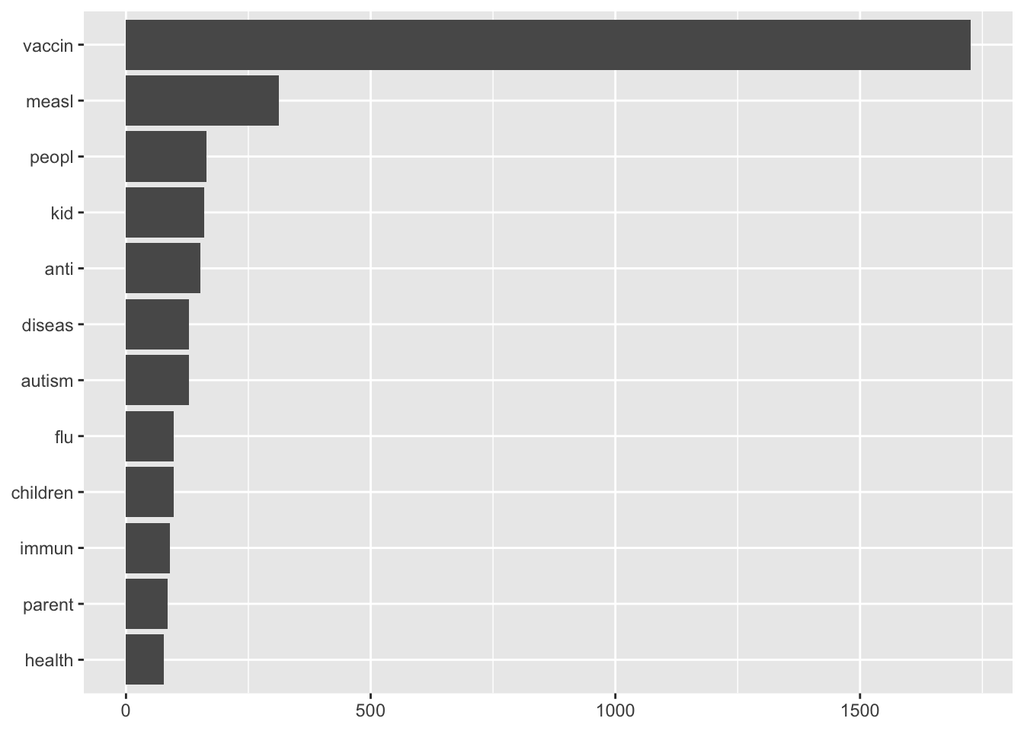

```r
unigram_count %>%
  top_n(12) %>%
  mutate(word = reorder(word, n)) %>%
  ggplot(aes(word, n)) +
  geom_col() +
  xlab(NULL) +
  ylab(NULL) +
  coord_flip()
```

Next, we can look at common *bigrams*, which are two words in a row. The tidytext function `unnest_tokens` is an efficient way to find bigrams by setting `token = "ngrams"` and `n = 2`. The output column is named “bigram”.

To get the most frequent bigrams we can simply use the `dplyr` library’s `count` function again.

```r
bigrams_stemmed <- text_df_stemmed %>%
  unnest_tokens(bigram, word, token = "ngrams", n = 2)

head(bigrams_stemmed)
```

```
##   int          bigram
## 1   1     addit abort
## 2   1   abort perform
## 3   1 perform continu
## 4   1   continu creat
## 5   1    creat vaccin
## 6   2     cell obtain
```

```r
head(bigrams_stemmed %>%
  dplyr::count(bigram, sort = TRUE),10)
```

```
## # A tibble: 10 x 2
##    bigram             n
##    <chr>          <int>
##  1 anti vaccin       75
##  2 measl vaccin      75
##  3 vaccin autism     61
##  4 flu vaccin        44
##  5 anti vaxxer       32
##  6 measl outbreak    32
##  7 chicken pox       31
##  8 vaccin kid        30
##  9 vaccin vaccin     30
## 10 mmr vaccin        28
```

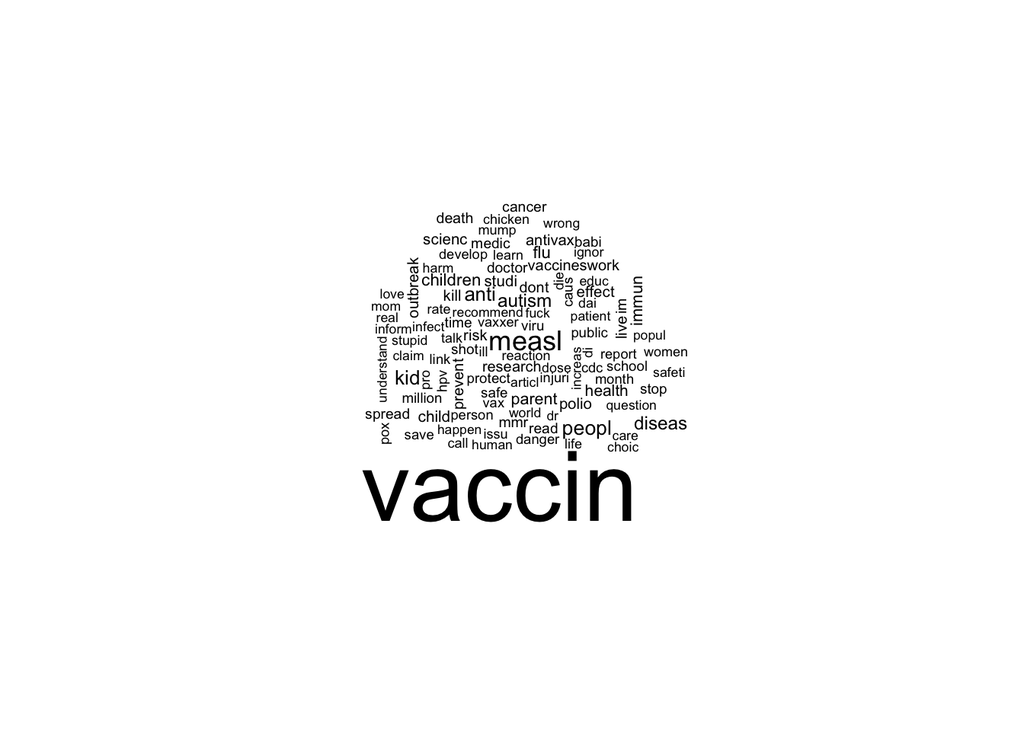

```r
unigram_count %>%
  with(wordcloud(word, n, max.words = 100))
```

## Sentiment

We want to classify the tweets by sentiment, or rather by the feelings and emotions portrayed by the user. As humans, we can usually tell if someone is angry, sad, satisfied, or even sarcastic. However we have to give the computer some clues on how to do this. We start with the `sentiments` dataset, which is loaded with the `tidytext` library. Similar to the `stop_words` dataset, there are three lexicons for each word:

- `afinn` gives each word an integer score between -5 and 5, from most negative to most positive sentiment.
- `bing` gives a binary “negative” or “positive” sentiment to each word.
- `nrc` assigns sentiment labels of “positive, negative, anger, anticipation, disgust, fear, joy, sadness, surprise, and trust.”

```r
head(sentiments)
```

```
## # A tibble: 6 x 2
##   word       sentiment
##   <chr>      <chr>
## 1 2-faces    negative
## 2 abnormal   negative
## 3 abolish    negative
## 4 abominable negative
## 5 abominably negative
## 6 abominate  negative
```

We can also use the tidytext’s `get_sentiments()` function to only get data from a particular lexicon.

```r
head(get_sentiments('afinn'))
```

```
## # A tibble: 6 x 2
##   word       value
##   <chr>      <dbl>
## 1 abandon       -2
## 2 abandoned     -2
## 3 abandons      -2
## 4 abducted      -2
## 5 abduction     -2
## 6 abductions    -2
```

The words in the first 6 rows of the above dataset happen to have a score of -2, indicating mildly negative sentiment.

To learn about how the `sentiments` dataset was constructed, read the following quote from [Chapter 2](https://www.tidytextmining.com/sentiment.html) of the online textbook, Text Mining with R:

*“How were these sentiment lexicons put together and validated? They were constructed via either crowdsourcing (using, for example, Amazon Mechanical Turk) or by the labor of one of the authors, and were validated using some combination of crowdsourcing again, restaurant or movie reviews, or Twitter data. Given this information, we may hesitate to apply these sentiment lexicons to styles of text dramatically different from what they were validated on, such as narrative fiction from 200 years ago. While it is true that using these sentiment lexicons with, for example, Jane Austen’s novels may give us less accurate results than with tweets sent by a contemporary writer, we still can measure the sentiment content for words that are shared across the lexicon and the text.”*

Next let’s merge our Twitter data with the sentiments data to explore the sentiment of the language used in the tweets. For a quick example, we will use the “afinn” lexicon and set the score to -2 to find some mildly negative words in the Twitter data.

First we use the `get_sentiments` function to get only the “afinn” lexicon data. We then filter the data so that we only have words with scores of -2.

```r
#nrc_example <- get_sentiments("afinn") %>%
#  filter(score == -2)

nrc_example <- get_sentiments("afinn") %>%
  filter(value == -2)
```

Next, we use the `inner_join` function to find words that are in both our Twitter dataset and in our sample sentiments dataset: words that have a sentiment score of -2. We sort them by the most frequent and print the first 10 rows with `head`.

```r
head(text_df %>%
  inner_join(nrc_example) %>%
  dplyr::count(word, sort = TRUE),10)
```

```
## # A tibble: 10 x 2
##    word               n
##    <chr>          <int>
##  1 flu               97
##  2 risk              47
##  3 death             31
##  4 wrong             25
##  5 stupid            22
##  6 injury            21
##  7 misinformation    20
##  8 sick              19
##  9 fear              14
## 10 ignorant          14
```

Since the “afinn” lexicon is numerical, we can plot the average “afinn” scores for each tweet to explore the overall sentiment of our data.

```r
library(tidyr)
head(text_df)
```

```
##   int       word
## 1   1 additional
## 2   1  abortions
## 3   1  performed
## 4   1   continue
## 5   1   creating
## 6   1    vaccine
```

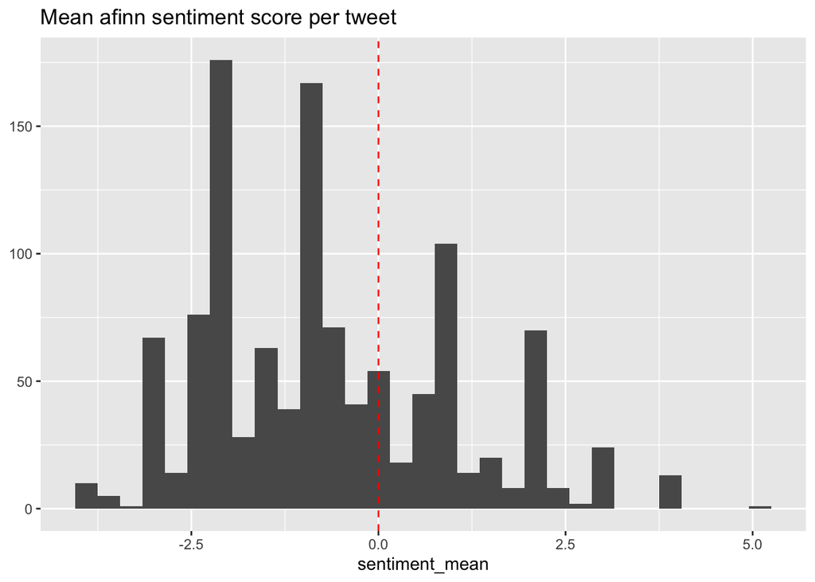

```r
#
# tweet_sentiment <- text_df %>%
#   inner_join(get_sentiments("afinn")) %>%
#   group_by(int) %>%
#   mutate(text = paste0(word)) %>%
#   summarize(sentiment_mean = mean(score))

tweet_sentiment <- text_df %>%
  inner_join(get_sentiments("afinn")) %>%
  group_by(int) %>%
  mutate(text = paste0(word)) %>%
  summarize(sentiment_mean = mean(value))

tweet_sentiment_ordered <- tweet_sentiment[order(tweet_sentiment$sentiment_mean),]

tweet_sentiment_ordered$int <- factor(tweet_sentiment_ordered$int, levels = tweet_sentiment_ordered$int)

ggplot(tweet_sentiment_ordered, aes(sentiment_mean)) +
  geom_histogram(show.legend = FALSE, binwidth = .3) +
  ggtitle("Mean afinn sentiment score per tweet") +
  geom_vline(xintercept = 0, linetype = "dashed", colour = "red") +
  ylab(NULL)
```

Let’s print out some positive tweets. We can use the index column “int” that we’ve kept constant to print out the original (sans and Twitter handles) tweets.

```r
positive <- tweet_sentiment$int[tweet_sentiment$sentiment_mean > 2]
head(tweets_df$text[positive])
```

```
## [1] "Not a fan of vaccines but I would have let him do it."
## [2] "Amen. You definitely are Perhaps go back to college and learn. I wish you the best of luck."
## [3] "For a bunch of vaccines - HiB tetanus rubella in which the rationale is prevention of congenital syndrome prevnar the justification isn't classroom health. I'd love an effective universal HIV vaccine that could be given prior to adolescence."
## [4] "My one year old got her measles vaccine today. I'm thrilled Thank you modern medicine"
## [5] "Love your furry friend back with the low cost vaccine clinic "
## [6] "Anna Durbin giving the Dean's Lecture on her work in developing a Dengue vaccine... fascinating story linking basic virology with global disease control "
```

And let’s look at some negative ones as well..

```r
negative <- tweet_sentiment$int[tweet_sentiment$sentiment_mean < -2 ]
head(tweets_df$text[negative])
```

```
## [1] "- million children died every year from Measles before the vaccine. "
## [2] "Good lord if there is a reason to distrust maybe its because there /are/ instances of vaccine injuries. People need to know what they are putting in their kids and at what risk. Im not saying metaphysical rock energy is a good alternative to modern medicine."
## [3] "Oh yes the hell there was. Many tainted vacines were traced coming from out sourced Pharphaceuiticals companies overseas that were not being properly tested. AMA is NOW making sure these Drugs Vaccines are being REGULATED."
## [4] "He's talking about killing - percent of people if his vaccine programs do really well. "
## [5] "It is very sad I hate that and as a parent that would probably make me question what I did wrong. There's just so much conflicting info and from what I've seen vaccines are doing more good than not"
## [6] "Nowhere in that does it say this baby died from vaccines. Just because the baby just got them doesn't mean that's the cause. Spreading stuff like this is a big problem."
```

Neither the positive nor negative tweets are unanimously pro- or anti-vax, even with this small sample of text. Because of this, we will not be able to use sentiment as a method to classify tweets, but rather as an evaluation metric.

# Data analysis

## Topic Modeling

Since our data is unsupervised, meaning we don’t have any prior knowledge or labels that tell us if a tweet is pro- or anti-vaccination, we are going to use *topic modeling* to separate the tweets into the two sides using only the text.

Latent Dirichlet allocation (LDA) is common topic modeling method: it views each document (or in our case, each tweet) as a mixture of topics, and each topic as a combination of words. A word can be part of multiple topics, thus allowing some overlap.

In order to apply LDA, we need to take our cleaned and “tidy” text data `text_df` and turn it into a *document term matrix* (DTM). It is easy to convert from the tidy text format to this matrix. First, we add a column counting the number of word repeats per tweet.

```r
dtm_df <- text_df_stemmed_common %>%
  group_by(int, word) %>%
  tally()

head(dtm_df)
```

```
## # A tibble: 6 x 3
## # Groups:   int [2]
##     int word        n
##   <dbl> <chr>   <int>
## 1     1 abort       1
## 2     1 addit       1
## 3     1 continu     1
## 4     1 creat       1
## 5     1 vaccin      1
## 6     2 abort       1
```

Next, we simply use the command `tidytext::cast_dtm` to convert to a document term matrix, a structure where each row is a document and each column is a word. You can explore the DTM in your console with the command `text_dtm$` followed by “i”, “j”, “v”, “nrow”, “ncol”, or “dimnames.”

```r
(text_dtm <- dtm_df %>%
  cast_dtm(int, word, n))
```

```
## <<DocumentTermMatrix (documents: 1495, terms: 1815)>>
## Non-/sparse entries: 14206/2699219
## Sparsity           : 99%
## Maximal term length: 23
## Weighting          : term frequency (tf)
```

```r
typeof(text_dtm)
```

```
## [1] "list"
```

```r
head(Terms(text_dtm))
```

```
## [1] "abort"   "addit"   "continu" "creat"   "vaccin"  "ago"
```

We see that the terms in the DTM are the words from each tweet.

```r
head(Docs(text_dtm))
```

```
## [1] "1" "2" "3" "4" "5" "7"
```

Now we are ready to apply LDA to our DTM. We set `k=2` because we are trying to create two categories of tweets: pro and anti vaccination. However, we should consider trying 3 categories later, the third being “other” tweets that are irrelevant to the debate. Note that we have no control over whether these will be the two or three clear categories, but it is the goal we are trying to achieve.

```r
(lda_k2 <- LDA(text_dtm, k = 2))#, #control = list(seed = 1234)))
```

```
## A LDA_VEM topic model with 2 topics.
```

Now that we have our model results, we must do some exploring in order to interpret them.

As mentioned previously, each word can be in multiple topics. To examine the probability that a certain word belongs to one of the topics, we can retrieve the “beta” values. This can be done easily by providing the function `tidy` our topic model.

```r
topics_k2 <- tidy(lda_k2, matrix = "beta")
head(topics_k2)
```

```
## # A tibble: 6 x 3
##   topic term        beta
##   <int> <chr>      <dbl>
## 1     1 abort   0.000376
## 2     2 abort   0.00104
## 3     1 addit   0.000594
## 4     2 addit   0.000178
## 5     1 continu 0.000184
## 6     2 continu 0.00136
```

Notice this dataframe is again in the “tidy” format with one word/topic per row.

Then we sort by the top terms and plot the data with `ggplot2`. In this case we filter by topic to show the differences.

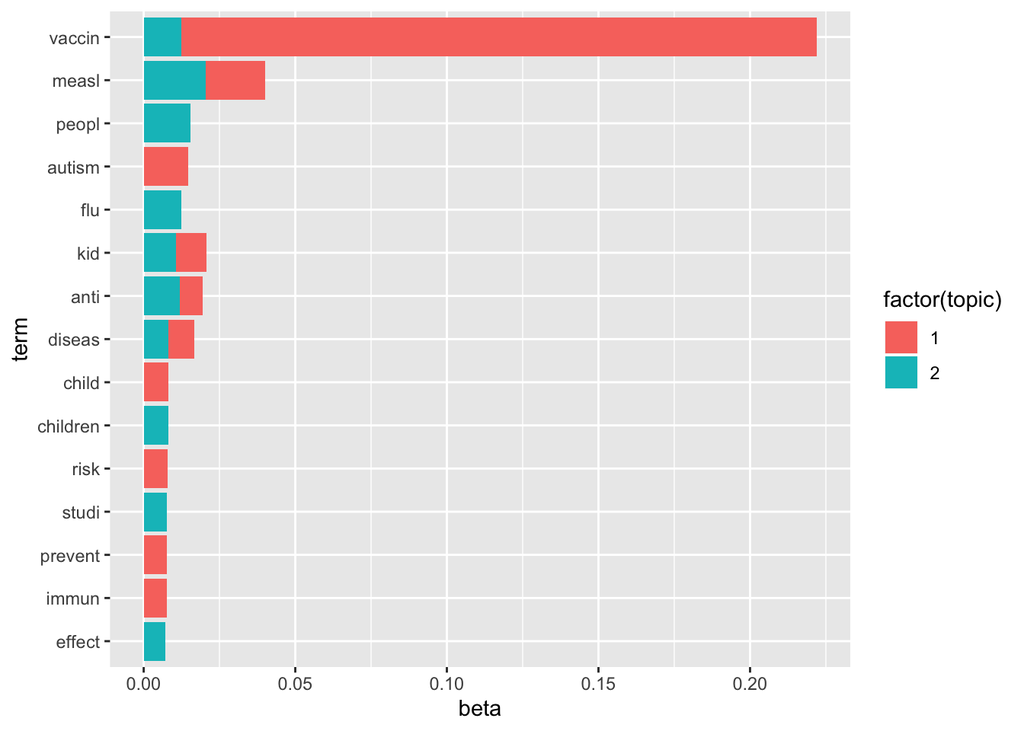

```r
top_terms <- topics_k2 %>%
  group_by(topic) %>%
  top_n(10, beta) %>%
  ungroup() %>%
  arrange(topic, beta)

top_terms %>%
  mutate(term = reorder(term, beta)) %>%
  ggplot(aes(term, beta, fill = factor(topic))) +
  geom_col(show.legend = TRUE) +
  coord_flip()
```

Some words overlap in each topic, but this is okay (and even good) because we know words such as “vaccine” can be used by both sides of this debate.

To look at the most polarizing words, i.e. words with the greatest difference between the beta values for topic 1 and 2 we can take the log ratio. We filter the `topics_k2` tidy dataframe to only have common words by setting `topic_x > .001`.

```r
beta_spread <- topics_k2 %>%
  mutate(topic = paste0("topic_", topic)) %>%
  spread(topic, beta) %>%
  filter(topic_1 > .001 | topic_2 > .001) %>%
  mutate(log_ratio = log2(topic_1 / topic_2))

head(beta_spread,10)
```

```
## # A tibble: 10 x 4
##    term     topic_1  topic_2 log_ratio
##    <chr>      <dbl>    <dbl>     <dbl>
##  1 abort   0.000376 0.00104     -1.47
##  2 absolut 0.000637 0.00104     -0.702
##  3 accept  0.000249 0.00117     -2.23
##  4 access  0.000151 0.00114     -2.92
##  5 actual  0.000126 0.00103     -3.04
##  6 adult   0.000113 0.00233     -4.37
##  7 advers  0.000455 0.00161     -1.82
##  8 ag      0.00261  0.000347     2.91
##  9 ago     0.000411 0.00101     -1.29
## 10 agre    0.00107  0.000732     0.546
```

```r
nrow(beta_spread)
```

```
## [1] 301
```

Next we filter the log ratio to display just a few common terms with the largest differences between beta values. Note that since our log ratio is $log(\frac{\beta_{topic_1}}{\beta_{topic_2}})$, if the beta value for topic 1 is larger, the log ratio will be positive. Again this means that the particular word is more likely to fall in topic 1 instead of 2. The reverse is true (if $\beta_{t2} > \beta_{t1}$, then the log is negative).

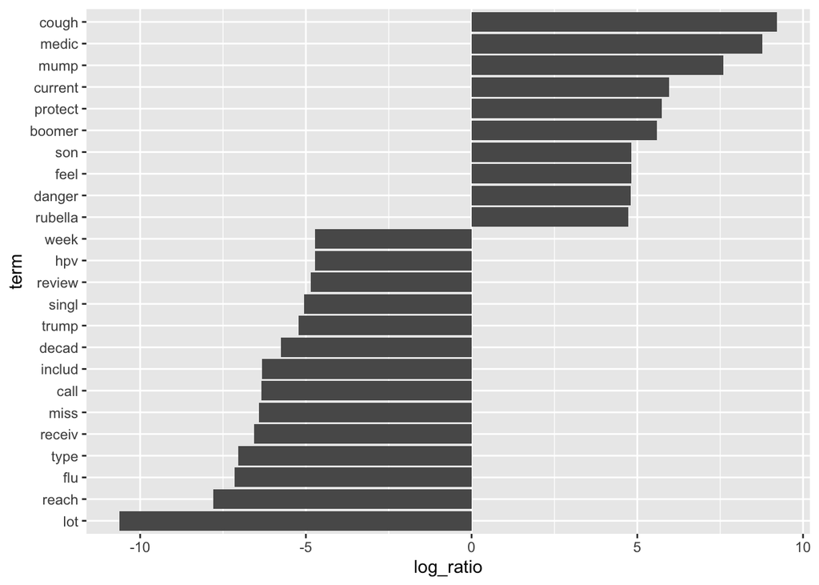

```r
beta_spread %>%
  filter(log_ratio > 4.5 | log_ratio< -4.5) %>%
  mutate(term = reorder(term, log_ratio)) %>%
  ggplot(aes(term, log_ratio)) +
  geom_col(show.legend = FALSE) +
  coord_flip()
```

The graph above displays words with the largest magnitude log ratios, out of the 301 most frequent words in either topic. The positive words are more likely to be in topic 1, and the negative words are more likely to be in topic 2.

### Examine group probabilities by tweet

Now that we have examined the *beta* values, or probability a word is in each topic, we now look at the *gamma* $(\gamma)$ probabilities or “per-document-per-topic probabilities.”

We create a new dataframe using `tidy()` and observe how it is arranged: for each topic and document combination (for this dataset, each document is a tweet), there is a gamma value between 0 and 1.

```r
lda_tweets <- tidy(lda_k2, matrix = "gamma")
head(lda_tweets)
```

```
## # A tibble: 6 x 3
##   document topic gamma
##   <chr>    <int> <dbl>
## 1 1            1 0.501
## 2 2            1 0.497
## 3 3            1 0.495
## 4 4            1 0.486
## 5 5            1 0.496
## 6 7            1 0.497
```

Next, we look at the tweets with the most extreme $\gamma$ values to get a sense of what we are working with.

```r
lda_tweets<-lda_tweets %>% arrange(desc(gamma))
head(lda_tweets)
```

```
## # A tibble: 6 x 3
##   document topic gamma
##   <chr>    <int> <dbl>
## 1 591          1 0.561
## 2 121          2 0.549
## 3 4825         2 0.549
## 4 976          2 0.544
## 5 613          1 0.543
## 6 1160         2 0.542
```

This doesn’t tell us that much until we actually read the tweets in relation to their assigned topics.

Let’s print the 20 tweets with the largest $\gamma$ scores,meaning they are the most skewed towards one topic or the other. We do this using the `kableExtra` library to make the twitter text nice and readable. We can also add a `scroll_box` to make a window that can be scrolled through when this file is knit to a HTML file.

```r
diff_tweets<-tweets_df$text[as.numeric(lda_tweets$document[1:20])]

diff_tweets<-data.frame(diff_tweets)
diff_tweets$topic <- as.numeric(lda_tweets$topic[1:20])

kable(diff_tweets) %>%
  kable_styling("striped", full_width = F) %>%
  scroll_box(width = "750px", height = "300px")
```

| diff_tweets | topic |
| --- | --- |
| The Vaccine Injury Compensation Trust Fund provides funding for the National Vaccine Injury Compensation ProgramFunded by a . excise tax on vaccines. Trivalent influenza vaccine is taxed . because it … | 1 |
| I just got the HPV vaccine because ya boy doesnt need dick cancer and the doctor was like you might get light headed afterwords and Im like yeah okay whatever.. homie stuck that needle in my arm and I… | 2 |
| School exemption day is week from today Under state law all children in public and private schools preschools Head Start and certified child care facilities must have up-to-date documentation on their… | 2 |
| This paper describes a case study in which an engineered man-made oncolytic virus built on a measles vaccine vector was targeted to multiple myeloma cells and promoted tumor regression in a single pat… | 2 |
| Billions of vaccines have been administered and a benefits-to-risk analysis can easily be drawn between vaccinated and unvaccinated populations between zero deaths and s of thousands. In this respect … | 1 |
| Youd be lucky to only get measles from the vaccineOther adverse reactions include Pancreatitis Type Diabetes Anaphylaxis Arthritis Encephalitis Aseptic Meningitis Pneumonia Deafness Retinitis Epididym… | 2 |
| Federal law does not require parental consent for vaccinations although the National Childhood Vaccine Injury Act does require that physicians provide a vaccine information statement… Instead a patchw… | 1 |
| #DYK immunization can protect infants children from serious illnesses permanent disability or even death? Immunizing on the recommended schedule starting at months of age is the best protection agains… | 1 |
| Dangerous antivax nonsense needs to be called out no matter who spreads it. I’m sure that is addressing your specific nonsense because you have a platform due to your proximity to Trump but it’s not b… | 2 |
| Not for nothing that link she tweeted is an aggregation of a CNN story which includes this line Then researchers gave her and five other multiple myeloma patients a dose of a highly concentrated lab-e… | 2 |
| If your child has not been vaccinated for measles that child is highly vulnerable to a deadly disease. Get the child vaccinated. Vaccines are safe | 1 |
| CANCELLEDToday’s Low Cost Dog Cat Vaccine Clinic has been cancelled due to the possibility of incoming inclement weather. For more information please contact the Community Development Department at - … | 2 |
| Vaccines Given Autism Rate in Vaccines Given Autism Rate in Vaccines Given Autism Rate in Vaccines Given Autism Rate in Wow it’s like Vaccines are a major cause of Autism or something? | 1 |
| Facebook mom I dont believe autism isnt caused by vaccines. The studies by actual scientists arent really accurateAlso Facebook mom I believe I can make a month selling this shitty makeup because a wo… | 2 |
| FDA is responsible vaccine safety licensing. In just-released court documents admits it has no safety data back up pregnancy recommendations. FDA has never formally approved any vaccines specifically … | 1 |
| I get the flu vaccine every year. I’ve never had the flu. The flu vaccine sometimes misses the target strain as they have to manufacture it before flu season begins and guess what it will be. You lear… | 2 |
| researchers gave her and five other multiple myeloma patients a dose of a highly concentrated lab-engineered measles virus similar to the measles vaccine….other patients in the trial did not go into r… | 2 |
| This tweet- to over THOUSAND followers- does more harm in its sec of being seen on twitter than the decades worth of data science and safety effectiveness research that have been done concerning #vacc… | 2 |
| It’s just hype.Inslee wants a state of emergency because it allows him to launder money under the radar since he doesn’t have to report it.Be honest about vaccines. I’m pro-vaccine AND pro-vaccine cho… | 1 |
| If the choice is a vaccine or polio I’ll take the vaccine. If the choice is a vaccine or a meningitis I’ll take the vaccine. If the choice is a pox or a vaccine I’ll take the vaccine. You’re selling s… | 1 |

It’s not obvious that there is a distinct difference between the two topic categories. In fact, there are some tweets that are clearly pro-vaccination in topic 2 but I also see some that are clearly anti-vaccination. This may be because this kind of topic modeling only looks at individual words such as “vaccine,” and not at bigrams or trigrams such as “vaccines work” and “vaccines cause autism.”

So let’s run a similar analysis but instead of starting with the one-token-per-row format, we start with the `bigrams` dataframe we created earlier. Take a look at the dataframe we just used for our analysis compared to `bigrams`:

```r
head(text_df_stemmed_common)
```

```
##   int    word
## 1   1   addit
## 2   1   abort
## 3   1 continu
## 4   1   creat
## 5   1  vaccin
## 6   2    cell
```

```r
head(bigrams_stemmed)
```

```
##   int          bigram
## 1   1     addit abort
## 2   1   abort perform
## 3   1 perform continu
## 4   1   continu creat
## 5   1    creat vaccin
## 6   2     cell obtain
```

The format is quite similar. Let’s proceed in converting `bigrams` to a document term matrix (DTM).

```r
dtm_bigram_df <- bigrams_stemmed %>%
  group_by(int, bigram) %>%
  tally()

head(dtm_bigram_df)
```

```
## # A tibble: 6 x 3
## # Groups:   int [2]
##     int bigram              n
##   <dbl> <chr>           <int>
## 1     1 abort perform       1
## 2     1 addit abort         1
## 3     1 continu creat       1
## 4     1 creat vaccin        1
## 5     1 perform continu     1
## 6     2 abort cell          1
```

```r
(bigram_dtm <- dtm_bigram_df %>%
  cast_dtm(int, bigram, n))
```

```
## <<DocumentTermMatrix (documents: 1495, terms: 13143)>>
## Non-/sparse entries: 16222/19632563
## Sparsity           : 100%
## Maximal term length: NA
## Weighting          : term frequency (tf)
```

```r
head(terms <- Terms(bigram_dtm))
```

```
## [1] "abort perform"   "addit abort"     "continu creat"   "creat vaccin"
## [5] "perform continu" "abort cell"
```

Now we apply LDA to this DTM as before.

This time, let’s try using `k = 3` to see if we can capture the following three topics:

- Anti-Vaccination
- Pro-Vaccination
- Irrelevant/No Opinion

```r
(lda_bi_k3 <- LDA(bigram_dtm, k = 3, control = list(seed = 1234)))
```

```
## A LDA_VEM topic model with 3 topics.
```

We get the beta values as before.

```r
bigram_beta <- tidy(lda_bi_k3, matrix = "beta")
head(bigram_beta)
```

```
## # A tibble: 6 x 3
##   topic term               beta
##   <int> <chr>             <dbl>
## 1     1 abort perform 1.84e-  4
## 2     2 abort perform 4.56e-169
## 3     3 abort perform 6.77e-169
## 4     1 addit abort   1.84e-  4
## 5     2 addit abort   7.37e-169
## 6     3 addit abort   2.69e-170
```

```r
bigram_gamma <- tidy(lda_bi_k3, matrix = "gamma")
bigram_gamma<-bigram_gamma %>% arrange(desc(gamma))
head(bigram_gamma)
```

```
## # A tibble: 6 x 3
##   document topic gamma
##   <chr>    <int> <dbl>
## 1 494          3 0.998
## 2 976          3 0.998
## 3 332          1 0.998
## 4 208          3 0.998
## 5 758          3 0.998
## 6 176          2 0.998
```

Wow! These $\gamma$ values are much higher than when we used unigrams and 2 topics. Let’s read the tweets to see how it did.

```r
diff_tweets<-tweets_df$text[as.numeric(bigram_gamma$document[1:20])]

diff_tweets<-data.frame(diff_tweets)
diff_tweets$topic <- as.numeric(bigram_gamma$topic[1:20])

kable(diff_tweets) %>%
  kable_styling("striped", full_width = F) %>%
  scroll_box(width = "750px", height = "300px")
```

| diff_tweets | topic |
| --- | --- |
| Dumb and WrongDarla Shine Wife of Top Trump Official Bill Shine Goes on Pro-Measles Anti-Vax Rant Bring back our #ChildhoodDiseases the former Fox News producer wrote they keep you healthy fight cance… | 3 |
| This paper describes a case study in which an engineered man-made oncolytic virus built on a measles vaccine vector was targeted to multiple myeloma cells and promoted tumor regression in a single pat… | 3 |
| Measles MMR vaccine protects against measles/mumps/rubella.Measles complications incl blindness encephalitis severe diarrhea/ dehydration ear infection resp infections like pneumonia.Measles harmful t… | 1 |
| Autistic disorder change point years are coincident with intro of vax’s manu’d using human fetal cell lines containing fetal and retroviral contaminants into childhood vaccine regimens. Thus rising au… | 3 |
| CANCELLEDToday’s Low Cost Dog Cat Vaccine Clinic has been cancelled due to the possibility of incoming inclement weather. For more information please contact the Community Development Department at - … | 3 |
| Follow evidence not belief.It’s how we got bridges cell phones vaccines and all else that makes our modern world derived from scientific progress. The HUGE balance of evidence is for manmade climate c… | 2 |
| Anti-vaxx is purely stupidI refuse to mince words nor pussyfoot around those blunt facts.Those diseases ARE NOT minor nor safe.Pre-Salk-vaccine my aunt got polio. It caused a miscarriage.After hospita… | 3 |
| Vaccines do NOT cause autism.Please do not trust checks Twitter profile professional athletes for your MEDICAL INFORMATION.Trust EVERY SINGLE DOCTOR NURSE MED STUD MA PA SURG TECH MEDICAL ASSOCIATION … | 3 |
| The Vaccine Injury Compensation Trust Fund provides funding for the National Vaccine Injury Compensation ProgramFunded by a . excise tax on vaccines. Trivalent influenza vaccine is taxed . because it … | 1 |
| These right-wing nuts are surely very Darwinian. Since they also deny poor people affordable health insurance - they are basically advocating murder.Strange way to run a country. Top Trump Official’s … | 1 |
| If you think pro-vaccine dr in question who was govt./vaccine industry expert witness defending vaccines works at Johns Hopkins has published s of scholarly articles isn’t reliable..That wd mean you’r… | 2 |
| Facebook mom I dont believe autism isnt caused by vaccines. The studies by actual scientists arent really accurateAlso Facebook mom I believe I can make a month selling this shitty makeup because a wo… | 1 |
| I watched a Vice piece about Chinese farmers using blockchain to track their products from farm to store. Theyre able to track the life of animals from the sticker on a packaged steak showing back to … | 1 |
| Are the moms who watched their beautiful children have adverse reactions to vaccines lying? Hallucinating? Why is it impossible to sue vaccine makers in a real court of law? Lets have a real talk no b… | 1 |
| Children get six dozen doses of vaccines that contain genetically engineered viruses bacteria plus ingredients like mercury aluminum formaldehyde phenoxyethanol gluteraldehyde proteins synthetic parti… | 1 |
| Read This Top Trump Official’s Wife Goes on #Pro -#Measles #AntiVaccine #Rant. This crap kills kids. Stop Them #Indivisible #Democrats #Progressives #Independents #TheResistance #Resist #BlueWave #Ind… | 2 |
| You quote selective articles supporting your bias from anti vaccine publications which selectively quote medical studies. Sadly many of those baby boomers you refer to who had measles as kids later di… | 2 |
| #STUDY in CID Jrn #Flu Shot Induces .-Fold INCREASE in Non-Flu Acute Respiratory InfectionsThis is a good VACCINATED vs. UNVACCINATED study where control group got real SALINE placebo not other vaccin… | 2 |
| Worst. Analogy. Ever.One can UNDO #seatbelts not #vaccinesOne can SUE seatbelt manufacturers not vaccine mnfctrsIf you sue you get DISCOVERY but not in vaccine courtGovt mandates vaccines for school b… | 2 |
| TODAY The #Dengue Human Infection Model…A Critical Tool for Development of a Safe and Effective #Vaccine. CIR faculty member Professor and #Flavivirus expert Dr. Anna P. Durbin explains this concept a… | 3 |

Topic 2 has many tweets that seem pro-vaccination. However the other two topics are difficult to distinguish.

# Summary of results

This analysis has demonstrated the difficulty of characterizing unsupervised text data. While we can create groups through topic summarization, we cannot quantify how accurate our algorithm works because we do not have any truth data.

One solution to having unlabeled data of this structure is to use a *semi-supervised* machine learning framework and completing a social network analysis. We can select *seed users*, or prominent figures that clearly have one opinion or another to create labels for part of the data. For example, the World Health Organization and CDC are two entities that would produce pro-vaccination tweets. Using social network analysis would allow us to use algorithms such as the Label Propagation Algorithm to identify users with the same opinion as these seed users. Structuring the network can be done in many different ways: we can connect users who retweeted one another or users that retweet the same tweet. We can also connect tweets by sentiment and key words.

In conclusion, Twitter data is fascinating to analyze: although it is messy and sparse, there is much insight to be gleaned from studying this data. Moreover, analysis can be completed in real time since there is a constant stream of tweets.

# Appendix

Here we illustrate how to generate unique IDs for each user and reconstruct the dataframe of tweets with this information. This is only necessary if you want to post the data and assumptions about the data. Please read the Twitter developer policies found [here](https://developer.twitter.com/en/developer-terms/agreement-and-policy.html).

Let `d` be the data we created and exported in the “What is the data?” section. First, use the function `dplR::uuid.gen` to generate unique IDs.

```r
unique_ids <- unique(c(d$user_id, d$retweet_user_id, d$quoted_user_id))

library(dplR)
ug <- uuid.gen()
uuids <- character(length(unique_ids))
for(i in 1:length(unique_ids)){
  uuids[i] <- ug()
}
```

We create a data frame `id_merge_df` with two columns: `unique_ids` has the unique user ids from users that created the tweets and those the tweets were retweeted from. The second column `uuidgens_user` contains a list of unique ids. We consider each row as an assignment of a unique id to a unique user.

```r
id_merge_df <- data.frame("unique_id" = unique_ids, "uuidgens_user" = uuids)
head(id_merge_df)

#Merge on the users
df_withIDs <- merge(d, id_merge_df, by.x = "user_id", by.y = "unique_id", all.x = TRUE, all.y = FALSE, sort = FALSE)

# Rename column to merge on the retweeted users
colnames(id_merge_df)[2]<-"uuidgens_retweet"
df_withIDs <- merge(df_withIDs, id_merge_df, by.x = "retweet_user_id", by.y = "unique_id", all.x = TRUE, all.y = FALSE, sort = FALSE)

# Rename columnd to merge on the quoted users
colnames(id_merge_df)[2]<-"uuidgens_quote"
df_withIDs <- merge(df_withIDs, id_merge_df, by.x = "quoted_user_id", by.y = "unique_id", all.x = TRUE, all.y = FALSE, sort = FALSE)

head(df_withIDs[c("user_id","uuidgens_user", "retweet_user_id", "uuidgens_retweet", "quoted_user_id","uuidgens_quote")])
```

Set the uuids that are associated with “na” to na.

```r
na_uuid <- id_merge_df$uuidgens_quote[is.na(id_merge_df$unique_id)]
print(na_uuid)
df_withIDs$uuidgens_retweet[df_withIDs$uuidgens_retweet == na_uuid]<-NA
df_withIDs$uuidgens_quote[df_withIDs$uuidgens_quote == na_uuid]<-NA
```

Next, save to a csv:

```r
write.csv(df_withIDs, file = "data_name.csv", row.names = FALSE, fileEncoding = "UTF-8")
```